# R Notebook

### Load necessary libraries

```r
packages.used=c("rvest", "tibble", "qdap",
                "sentimentr", "gplots", "dplyr",
                "tm", "syuzhet", "factoextra",
                "beeswarm", "scales", "RColorBrewer",
                "RANN", "tm", "topicmodels","stringr","maps","countrycode","rworldmap")

# check packages that need to be installed.
packages.needed=setdiff(packages.used,
                        intersect(installed.packages()[,1],
                                  packages.used))
# install additional packages
if(length(packages.needed)>0){
  install.packages(packages.needed, dependencies = TRUE)
}

# load packages
library("rvest")
library("tibble")
library("qdap")
library("sentimentr")
library("gplots")
library("dplyr")
library("tm")
library("syuzhet")
library("factoextra")
library("beeswarm")
library("scales")
library("RColorBrewer")
library("RANN")
library("tm")
library("topicmodels")
library("tidytext")
library("ggplot2")
library("stringr")
library("maps")
library("countrycode")
library("rworldmap")

source("../lib/plotstacked.R") # not used
source("../lib/speechFuncs.R") # not used
```

### Get meta data from xlsx file

```r
library("xlsx")
library("rJava")
library("xlsxjars")
inaug =read.xlsx(file.path("..","data","InaugurationInfo.xlsx",fsep = .Platform$file.sep),1)
inaug$File = NULL
inaug$Words = NULL
```

### Let’s get our inaugural speeches into a corpus

```r
library(tm)
ds = DirSource(directory = file.path("..","data","InauguralSpeeches",fsep = .Platform$file.sep),
               pattern = "*.txt",
               mode = "text")
corpus = VCorpus(ds,readerControl = list(reader=ds$reader,language="en"))
```

# Check to ensure that speeches were correctly imported

```r
corpus[[1]]$content
```

[output not shown]

# Convert speeches into a Tibble data frame

```r
# loop over corpus to get
rawtext = NULL
for(i in seq(length(corpus))) {
  rawtext[i] <- corpus[[i]]$content
}
```

```
number of items to replace is not a multiple of replacement length
```

```r
# create a tibble
tb_speeches = tibble(author=inaug$President,
            party=inaug$Party,
            text=rawtext,
            term=inaug$Term)
```

### For the first task, let’s split the speeches into sentences and try to figure out whether the speeches are more “positive” or “negative” on balance. We split the text into sentences because whole paragraphs tend to average out positive and negative sentiments. We’ll assign sentiments to sentences using the NRC method.

```r
tb_sentences <- tb_speeches %>%
  group_by(author) %>%
  unnest_tokens(sentence, text, token = "sentences")
tb_sentences$score <- get_sentiment(tb_sentences$sentence, method = "nrc")
```

### Let’s see which Presidents have the highest mean sentiment scores (calculated over the sentences in their inaugural address) based on the NRC scoring method.

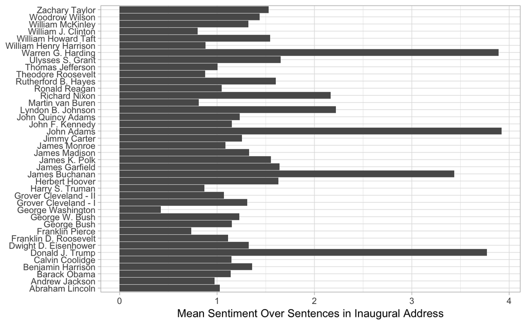

```r
mean_scores <- tb_sentences %>%
  group_by(author) %>%
  summarise(mean(score))
mean_scores$score <- mean_scores$`mean(score)` # change annoying column name.  There's prob a better way
mean_scores$`mean(score)` <- NULL
ggplot(mean_scores,aes(author,score)) +
  geom_bar(stat = "identity", show.legend = FALSE) +
  labs(y = "Mean Sentiment Over Sentences in Inaugural Address",
       x = NULL) +
  coord_flip()
```

```r
# ideally would like to be able to sort by the top sentiment scores to the bottom
```